# Develop screening model based on FAISS outputs

Author

O’Hara

This script takes the .csv files output by `1_faiss_criteria_query.qmd` and insights from `2_faiss_examine_results.qmd` to develop and train a screening model for the overall citation set.

- For each phrase category (remote sensing, societal benefit, valuation methodology) identify the phrase with the greatest similarity (lowest score) and keep only that.
- Examine how well remaining phrases can predict inclusion vs exclusion on the SBR
  - Try various models: logistic regression, random forest, maybe neural networks
  - Model selection using cross validation in `tidymodels` package
  - Examine success metrics e.g., AUC to identify potential thresholds for exclusion

```r
library(tidyverse)
library(ggfortify)   ### for PCA plots
library(here)
library(tidymodels)
library(corrplot)
```

## Load query results

```r
faiss_query_fs <- list.files(here('3_sentence_transformer_similarity_ranking',
                                  'faiss_out'), pattern = 'faiss_min',
                                  full.names = TRUE)

faiss_q_df <- lapply(faiss_query_fs, FUN = function(f) {
  ## f <- faiss_query_fs[1]
  q <- basename(f) %>% str_remove_all('faiss_min_|.csv')
  df <- read_csv(f, show_col_types = FALSE) %>%
    mutate(query = q) %>%
    select(dist, query, citation)
}) %>%
  bind_rows() %>%
  mutate(criteria = str_extract(query, '^[a-z]'),
         query = str_remove(query, '[a-z]_'))
```

## Load references from Societal Benefits Repository

We can compare the screened results from the SBR to the distance values here, perhaps via PCA, clustering, logistic regression…

Note: `_data/societal_benefits/sbr_screened_results_240429.csv` is the citation screening results; `_output/societal_benefits/fulltext_screened.csv` is the full text screening results (does not include those excluded in the citation screening).

```r
cit_scr_df <- read_csv(here('_data/societal_benefits/sbr_screened_results_240429.csv')) %>%
  mutate(title = str_to_title(title))

fulltext_df <- read_csv(here('_output/societal_benefits/fulltext_screened.csv')) %>%
  ### skip author, match by title only?
  select(title, screening_decision, reason_for_exclusion, notes = `Quick notes`) %>%
  mutate(title = str_to_title(title))

screened_df <- cit_scr_df %>%
  full_join(fulltext_df) %>%
  mutate(decision = ifelse(is.na(screening_decision), screening_status, tolower(screening_decision))) %>%
  mutate(decision = str_replace(decision, 'cluded', 'clude'))


rescale <- function(x) {
  1 - (x - min(x)) / (max(x) - min(x))
}

sbr_vs_faiss <- screened_df %>%
  select(author, title, decision, tags, key) %>%
  left_join(faiss_q_df, by = c('key' = 'citation')) %>%
  ### find the lowest distance among queries in the category
  # group_by(author, title, criteria) %>%
  # filter(dist == min(dist)) %>%
  ### convert distance to relevance: low distance = high relevance
  group_by(query) %>%
  mutate(dist_norm = rescale(dist)) %>%
  ungroup()
```

## Examine collinearity

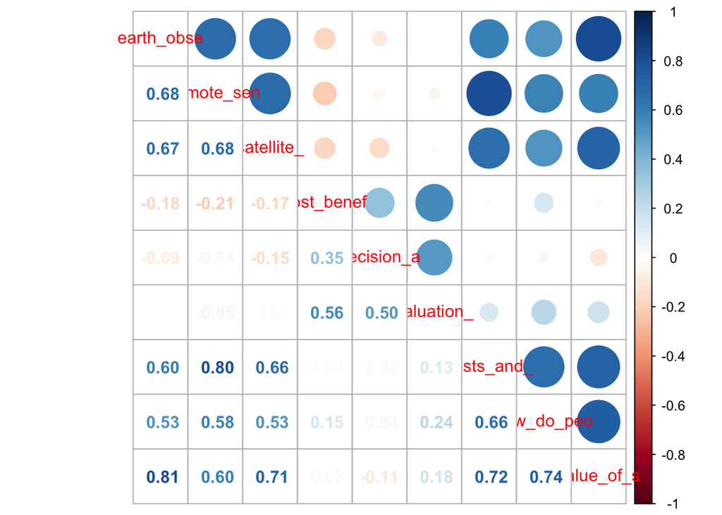

```r
sbr_faiss_wide <- sbr_vs_faiss %>%
  filter(!is.na(query)) %>%
  filter(!criteria %in% c('b')) %>% ### drop societal benefits queries?
  select(-dist, -key, -criteria) %>%
  mutate(query = str_sub(query, 1, 10)) %>%
  pivot_wider(names_from = 'query', values_from = 'dist_norm')

sbr_faiss_mtx <- sbr_faiss_wide %>%
  select(-author, -title, -decision, -tags) %>%
  as.matrix()

corr_mtx <- cor(sbr_faiss_mtx)
corrplot.mixed(corr_mtx)
```

## Examine relationships via PCA

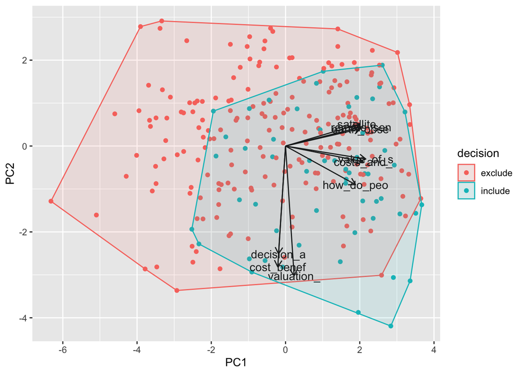

```r
# set.seed(42)
sbr_faiss_pca <- sbr_faiss_wide %>%
  select(where(is.numeric)) %>%
  scale() %>%
  prcomp()

pca_df <- as.data.frame(sbr_faiss_pca$x) %>%
  mutate(decision = sbr_faiss_wide$decision)

pca_hull_df <- pca_df %>%
  arrange(decision, PC1, PC2) %>%
  group_by(decision) %>%
  slice(chull(PC1, PC2))

pca_rot_df <- data.frame(sbr_faiss_pca$rotation %>% round(4) * 5) %>%
  mutate(query = rownames(.))

p12 <- ggplot(pca_df, aes(x = PC1, y = PC2)) +
  geom_point(aes(color = decision)) +
  geom_segment(data = pca_rot_df, x = 0, y = 0,
               aes(xend = PC1, yend = PC2),
               arrow = arrow(length = unit(.1, 'inches'))) +
  geom_text(data = pca_rot_df, aes(label = query)) +
  geom_polygon(data = pca_hull_df,
               aes(x = PC1, y = PC2, color = decision, fill = decision), alpha = .1)

p12
```

The collinearity at least within the first two principal components is clear in the biplot. While there is a lot of overlap between the includes and excludes, there’s a pretty decent chunk of excluded documents that do not overlap at all. Identifying thresholds to drop those would save a substantial amount of time when proceeding to a manual citation screening.

Let’s examine between PC 3 and 4:

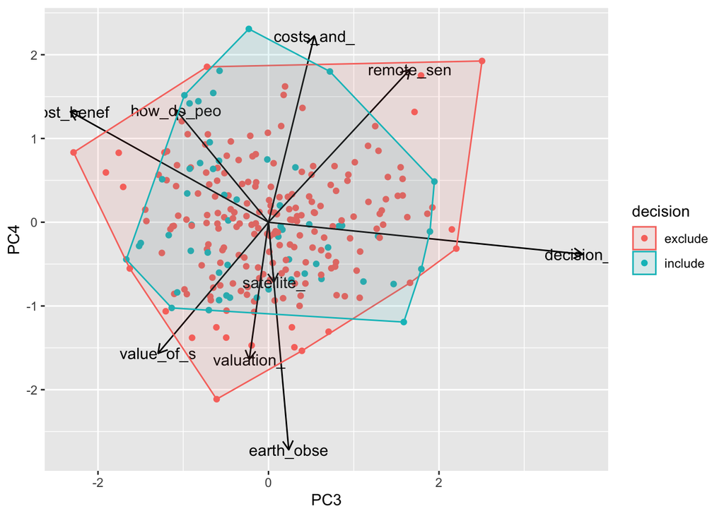

```r
pca_hull_df <- pca_df %>%
  arrange(decision, PC3, PC4) %>%
  group_by(decision) %>%
  slice(chull(PC3, PC4))

pca_rot_df <- data.frame(sbr_faiss_pca$rotation %>% round(4) * 5) %>%
  mutate(query = rownames(.))

p34 <- ggplot(pca_df, aes(x = PC3, y = PC4)) +
  geom_point(aes(color = decision)) +
  geom_segment(data = pca_rot_df, x = 0, y = 0,
               aes(xend = PC3, yend = PC4),
               arrow = arrow(length = unit(.1, 'inches'))) +
  geom_text(data = pca_rot_df, aes(label = query)) +
  geom_polygon(data = pca_hull_df,
               aes(x = PC3, y = PC4, color = decision, fill = decision), alpha = .1)

p34
```

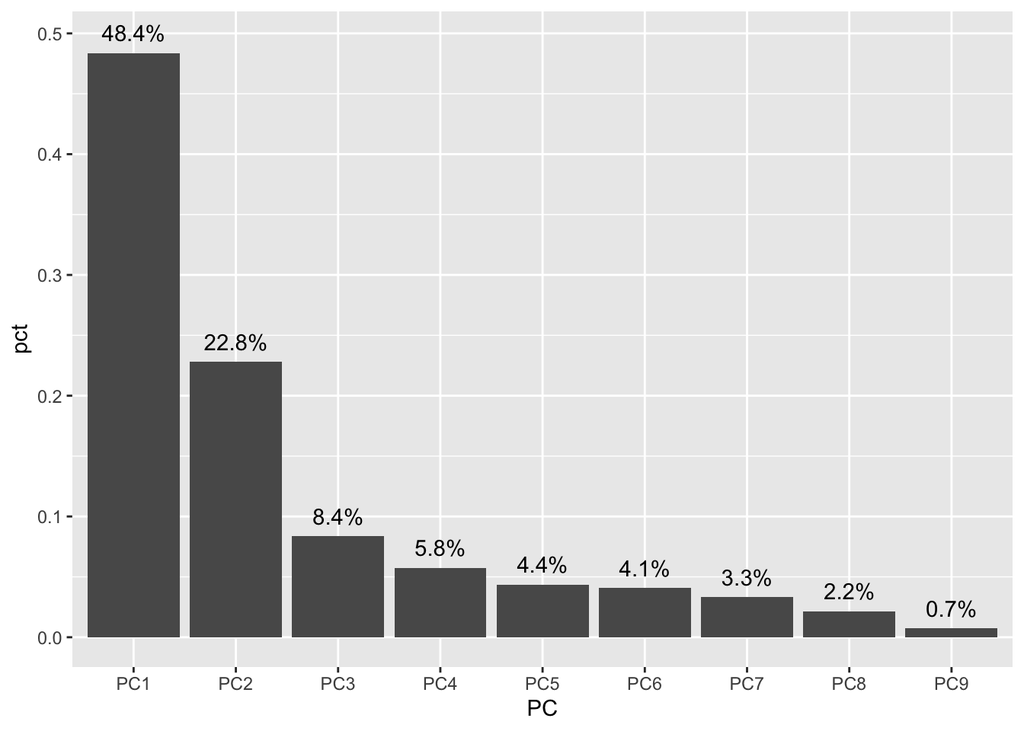

```r
scree_df <- data.frame(PC = paste0('PC', 1:length(sbr_faiss_pca$sdev)),
                       pct = (sbr_faiss_pca$sdev)^2 / sum((sbr_faiss_pca$sdev)^2)) %>%
  mutate(PC = fct_inorder(PC),
         lbl = paste0(round(pct * 100, 1), '%'),
         cumsum = cumsum(pct))

ggplot(scree_df, aes(x = PC, y = pct)) +
  geom_col() +
  geom_text(aes(label = lbl), vjust = 0, nudge_y = .01)
```

```r
knitr::kable(pca_rot_df %>% select(PC1:PC4))
```

|  | PC1 | PC2 | PC3 | PC4 |
| --- | --- | --- | --- | --- |
| earth_obse | 2.0185 | 0.4020 | 0.2375 | -2.7180 |
| remote_sen | 2.0395 | 0.4440 | 1.6590 | 1.8240 |
| satellite_ | 2.0065 | 0.5145 | 0.0630 | -0.7175 |
| cost_benef | -0.2090 | -2.8135 | -2.3240 | 1.3210 |
| decision_a | -0.1890 | -2.5105 | 3.6865 | -0.3820 |
| valuation_ | 0.2315 | -3.0205 | -0.2255 | -1.6390 |
| costs_and_ | 2.0910 | -0.3650 | 0.5375 | 2.2245 |
| how_do_peo | 1.8855 | -0.8985 | -1.0845 | 1.3395 |
| value_of_s | 2.1635 | -0.3025 | -1.2960 | -1.5660 |

## Let’s try some predictive models

```r
set.seed(42)
sbr_split <- initial_split(sbr_faiss_wide %>%
                             mutate(decision = factor(decision)) %>%
                             select(decision, where(is.numeric)),
                           prop = .80, strata = decision)

sbr_test_df <- testing(sbr_split)
sbr_train_df <- training(sbr_split)

sbr_train_folds <- vfold_cv(sbr_train_df, v = 5)
```

### Binary logistic regression

Set up the model, then set up a workflow. Using this workflow, resample for k-fold cross validation.

```r
blr_mdl <- logistic_reg() %>%
  set_engine('glm')

blr_wf <- workflow() %>%
  add_model(blr_mdl) %>%
  add_formula(decision ~ .)

blr_fit_folds <- blr_wf %>%
  fit_resamples(sbr_train_folds)

collect_metrics(blr_fit_folds)
```

```
# A tibble: 2 × 6
  .metric  .estimator  mean     n std_err .config
  <chr>    <chr>      <dbl> <int>   <dbl> <chr>
1 accuracy binary     0.774     5  0.0203 Preprocessor1_Model1
2 roc_auc  binary     0.694     5  0.0269 Preprocessor1_Model1
```

```r
# glm(decision ~ ., data = sbr_train_df, family = 'binomial') %>% summary
```

### Random forest

```r
rf_mdl <- rand_forest(trees = 1000) %>%
  set_engine('ranger') %>%
  set_mode('classification')

rf_wf <- workflow() %>%
  add_model(rf_mdl) %>%
  add_formula(decision ~ .)

rf_fit_folds <- rf_wf %>%
  fit_resamples(sbr_train_folds)

collect_metrics(rf_fit_folds)
```

```
# A tibble: 2 × 6
  .metric  .estimator  mean     n std_err .config
  <chr>    <chr>      <dbl> <int>   <dbl> <chr>
1 accuracy binary     0.755     5  0.0248 Preprocessor1_Model1
2 roc_auc  binary     0.672     5  0.0570 Preprocessor1_Model1
```

## Compare last fits

```r
blr_last <- blr_wf %>%
  last_fit(sbr_split)

rf_last  <- rf_wf %>%
  last_fit(sbr_split)

collect_metrics(blr_last)
```

```
# A tibble: 2 × 4
  .metric  .estimator .estimate .config
  <chr>    <chr>          <dbl> <chr>
1 accuracy binary         0.811 Preprocessor1_Model1
2 roc_auc  binary         0.839 Preprocessor1_Model1
```

```r
collect_metrics(rf_last)
```

```
# A tibble: 2 × 4
  .metric  .estimator .estimate .config
  <chr>    <chr>          <dbl> <chr>
1 accuracy binary         0.830 Preprocessor1_Model1
2 roc_auc  binary         0.888 Preprocessor1_Model1
```

Based on this, both models seems to do a good job of prediction. However, we are more concerned about false negatives (rejecting a document that should be included) than false positives (including a document that should be excluded), and our dataset is a bit unbalanced (~20% inclusion) and the full dataset is likely to be far more unbalanced, so these “success metrics” are likely driven by high true negative rates. Let’s pull info out of the `rf_last`, and plot a ROC and confusion matrix to see if there’s a good threshold for probability that drops true negatives but doesn’t drop many true positives…

```r
mdl_check_df <- rf_last$.predictions[[1]]

mdl_check_df %>% select(.pred_class, decision) %>% table()
```

```
           decision
.pred_class exclude include
    exclude      41       9
    include       0       3
```

```r
mdl_check_df %>%
  filter(decision == 'include' | .pred_class == 'include') %>%
  arrange(.pred_include)
```

```
# A tibble: 12 × 6
   .pred_exclude .pred_include  .row .pred_class decision .config
           <dbl>         <dbl> <int> <fct>       <fct>    <chr>
 1         0.942        0.0579   120 exclude     include  Preprocessor1_Model1
 2         0.774        0.226    229 exclude     include  Preprocessor1_Model1
 3         0.716        0.284     69 exclude     include  Preprocessor1_Model1
 4         0.711        0.289     14 exclude     include  Preprocessor1_Model1
 5         0.711        0.289     78 exclude     include  Preprocessor1_Model1
 6         0.669        0.331     52 exclude     include  Preprocessor1_Model1
 7         0.669        0.331    203 exclude     include  Preprocessor1_Model1
 8         0.594        0.406    102 exclude     include  Preprocessor1_Model1
 9         0.533        0.467    100 exclude     include  Preprocessor1_Model1
10         0.427        0.573    173 include     include  Preprocessor1_Model1
11         0.381        0.619     73 include     include  Preprocessor1_Model1
12         0.296        0.704    219 include     include  Preprocessor1_Model1
```

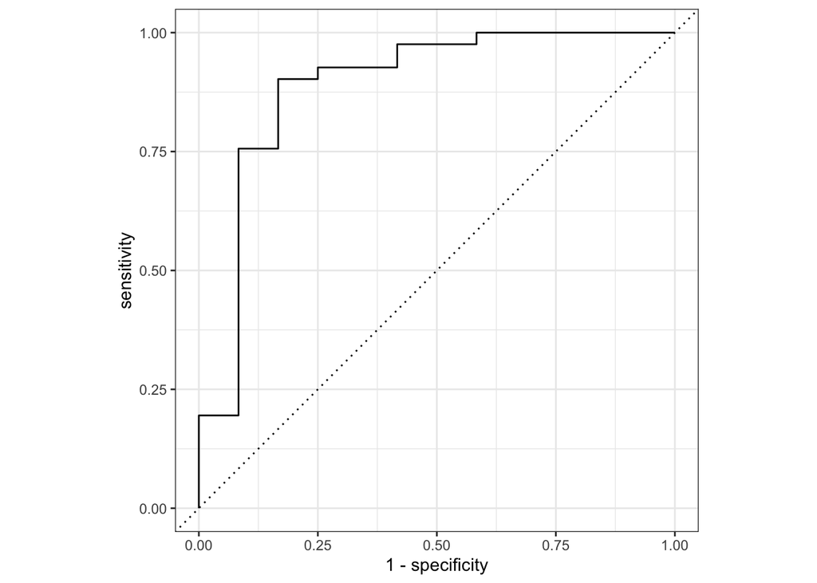

```r
roc_curve(mdl_check_df, truth = decision, .pred_exclude) %>%
  autoplot()
```

## Which documents are classified as false negatives?

Examine the false negatives, including the queries with the lowest similarity values (these are rescaled distance values, so 0 = highest distance = lowest similarity, 1 = lowest distance = highest similarity).

```r
false_neg_indices <- mdl_check_df %>%
  filter(decision == 'include' & .pred_class == 'exclude') %>%
  arrange(.pred_include) %>%
  pull(.row)

cites_to_check <- sbr_faiss_wide %>%
  mutate(across(where(is.numeric), ~round(.x, 3))) %>%
  slice(false_neg_indices)

write_csv(cites_to_check, 'cites_to_check.csv')
```